# Hierarchical Clustering with Spatial Constraint

## Hierarchical Clustering with Spatial Constraint

Using a similar approach to the previous post, we’ll first use only the aggregated calle data with the ZAT data (indicator matrix `D0`) for the clustering process to determine the cluster number.

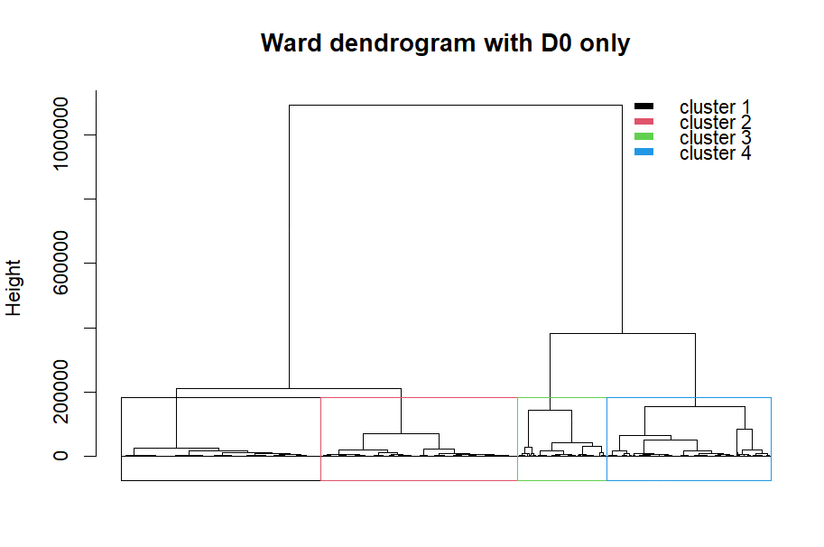

Keeping the cluster number as 4, we’ll calculate the neighborhood distance matrix (`D1`) using the network distance. To choose a mixing parameter, we’ll take a look at the homogeneity plot:

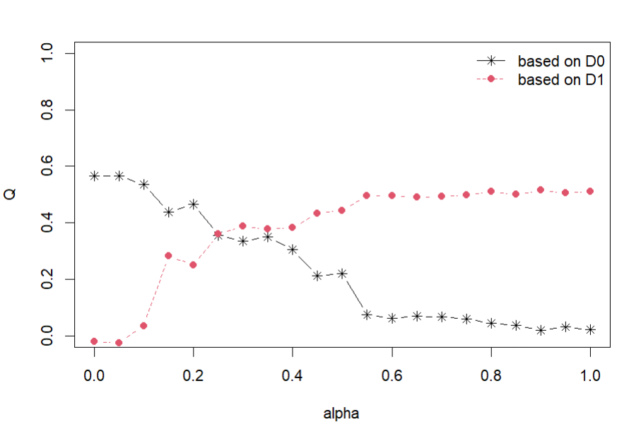

Choosing 0.25 as the mixing parameter, we can perform the hierarchical clustering and visualize the result:

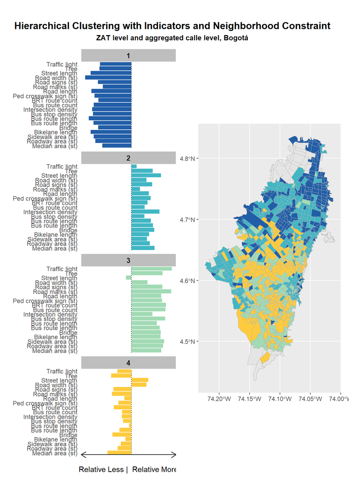

```r
pal <- c("#225ea8","#41b6c4","#a1dab4","#fecb3e")
source("../../../../functions/cluster_plot.R")

map_clust <- ggplot()+
  geom_sf(data = zat_shapefile %>% st_zm(), color = "grey70")+
  geom_sf(data = calle2zat_geo, color = "grey70", fill = pal[calle2zat_geo$clus])

(cluster_plot(calle2zat_clust) | map_clust ) +
  plot_annotation('Hierarchical Clustering with Indicators and Neighborhood Constraint',
    subtitle = 'ZAT level and aggregated calle level, Bogotá',
    theme=theme(plot.title=element_text(size=14, face = "bold", hjust=0.5),
                plot.subtitle = element_text(size = 10, face = "bold", hjust = 0.5))) +
  plot_layout(width = c(1, 1.5), height = unit(20, "cm"))
```

## Traffic flow and Population

To visualize and compare the neighborhood profile with traffic flow (total walking trips and public transit trips) and population at the ZAT level:

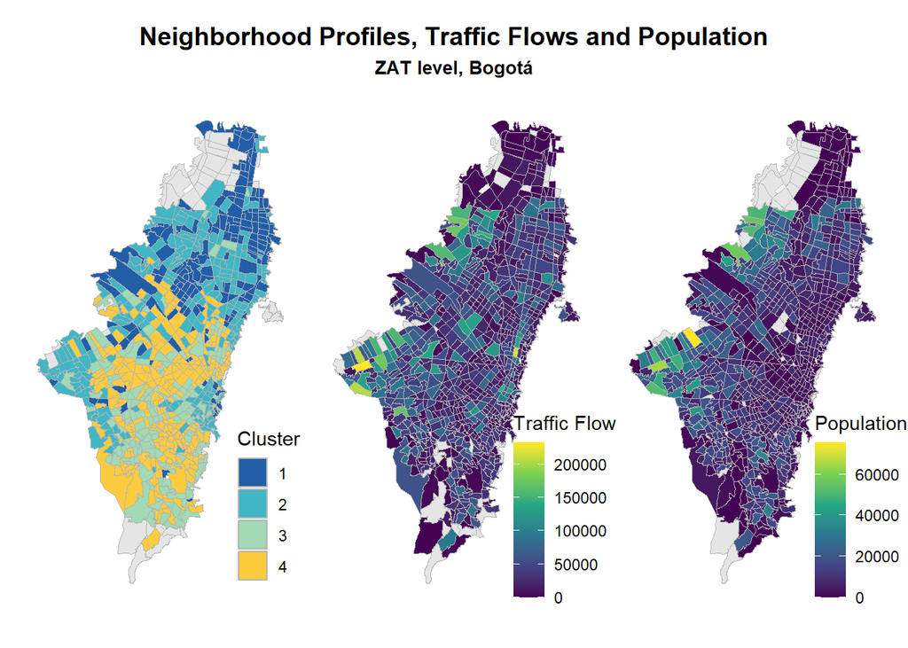

```r
#traffic flow
total_trips <- readRDS("../../../../data/zat_denom.rds")

walk_transit <- total_trips %>%
  select(ZAT, total_walk, total_pubt) %>%
  mutate(flow = total_walk+total_pubt) %>%
  select(-total_walk, -total_pubt)

walk_transit_geo <- walk_transit %>%
  left_join(zat_shapefile, by = "ZAT") %>%
  filter(!st_is_empty(geometry)) %>%
  st_as_sf() %>%
  st_zm()

map_flow <- ggplot()+
  geom_sf(data = zat_shapefile %>% st_zm(), color = "grey70")+
  geom_sf(data = walk_transit_geo, aes(fill = flow), color = "grey70")+
  scale_fill_viridis_c() +
  labs(fill = "Traffic Flow")+
  theme_minimal()+  # note the order of adjusting theme
  theme(
    legend.position = c(0.9, 0.2),
    axis.text = element_blank(),
    panel.grid = element_blank()
  )

# population
pop <- read_excel("../../../../data/pop_zat.xlsx")

zat_pop2021 <- pop %>%
  select(ZAT, POBD2021) %>%
  left_join(zat_shapefile, by = "ZAT") %>%
  filter(!st_is_empty(geometry)) %>%
  st_as_sf() %>%
  st_zm()


map_pop <- ggplot() +
  geom_sf(data = zat_shapefile %>% st_zm(), color = "grey70") +
  geom_sf(data = zat_pop2021, color = "grey70", aes(fill = POBD2021)) +
  scale_fill_viridis_c() +
  labs(fill = "Population")+
  theme_minimal()+
  theme(
    legend.position = c(0.9, 0.2),
    axis.text = element_blank(),
    panel.grid = element_blank()
  )

map_clust2 <- ggplot()+
  geom_sf(data = zat_shapefile %>% st_zm(), color = "grey70")+
  geom_sf(data = calle2zat_geo, color = "grey70", aes(fill = factor(clus)))+
  scale_fill_manual(values = pal) +
  labs(fill = "Cluster")+
  theme_minimal()+
  theme(
    legend.position = c(0.9, 0.2),
    axis.text = element_blank(),
    panel.grid = element_blank()
  )

(map_clust2 | map_flow | map_pop)+
  plot_annotation('Neighborhood Profiles, Traffic Flows and Population',
    subtitle = 'ZAT level, Bogotá',
    theme=theme(plot.title=element_text(size=14, face = "bold", hjust=0.5),
                plot.subtitle = element_text(size = 10, face = "bold", hjust = 0.5)))
```